# The Illusion of Momentum: What Tennis Data Reveals About the Myth of the Hot Hand

Author

Flynn Presence

It is the fourth set of the 2023 Wimbledon final. Carlos Alcaraz, twenty years old, has just saved a break point with a forehand winner down the line that the crowd will talk about for years. The commentators erupt. Novak Djokovic, standing at the baseline with twenty-three Grand Slam titles behind him, rolls his neck and bounces on his toes. The stadium is unanimous: something has shifted. The momentum, every pundit agrees, belongs to Alcaraz now.

He went on to win the match. And the narrative wrote itself.

The crowd saw a turning point. The commentators called it a psychological breakthrough. Djokovic’s body language told the same story. In that moment, fifteen thousand people in the stands and millions watching at home reached the same conclusion: winning that break point had changed something fundamental about the match. The next points, they felt, would follow inevitably.

But here is the question that data forces us to ask: did winning that point actually make the next one more likely to go his way? Or did the crowd, the commentators, and even Djokovic himself fall for one of sport’s oldest statistical illusions?

The debate over momentum in sport is older than professional tennis itself. In 1985, psychologists Gilovich, Vallone and Tversky published what became the most cited paper in sports statistics, arguing that the “hot hand” in basketball was a cognitive illusion. Fans and players were pattern-matching on random sequences, seeing structure in noise. Their conclusion was blunt: streaks happen by chance, and momentum is a story we tell ourselves.

The debate never settled. In 2018, economists Miller and Sanjurjo showed that Gilovich’s original analysis contained a subtle mathematical flaw: a streak selection bias that caused genuine persistence in performance to be systematically underestimated. The hot hand, they argued, had been buried prematurely.

More recently, Du et al. (2025) attempted to validate momentum in tennis using analysis and machine learning across just 31 Wimbledon matches. They found evidence of momentum — but 31 matches is a thin foundation for a claim this bold, and their approach conflates correlation with causation.

This project tests the same claim at a scale that has never been attempted before, and with a stricter method. We analysed every point played across all four 2023 Grand Slams — the Australian Open, Roland Garros, Wimbledon and the US Open — across both the ATP and WTA tours. That is 52,314 points, 275 matches, and 155 players. And we did not just look for correlation. We looked for causation. What we found is more interesting than a simple yes or no.

## The Data: Every Point, Every Grand Slam

The raw data comes from Jeff Sackmann’s Match Charting Project, a publicly available, volunteer-compiled database where tennis analysts manually record every point played in professional matches, including the exact score state at each moment. This allowed us to identify the highest-pressure situations in the game with precision: break points, where the returner stands one point away from winning the service game, and tiebreak points, where an entire set hangs in the balance. We called these high-leverage moments. Across the ATP tour, 27% of all points fell into this category. The ATP dataset comprises 35,635 points across 155 matches, while the WTA dataset covers 16,679 points across 120 matches — the difference reflecting the longer best-of-five format used by men at Grand Slams.

Before any analysis could begin, the raw data required substantial preparation: matching player names across separate datasets, filtering to main draw matches only — qualifying rounds were excluded because they feature significantly lower-ranked players under different competitive conditions — removing retirements and walkovers, and standardising score formats across tens of thousands of individual points. We also drew on official ATP and WTA rankings to measure each player’s baseline skill level — consistent with Kovalchik and Reid (2017), who found player ranking to be the strongest baseline predictor of match outcomes — ensuring that any effect we found could not simply be explained by better players playing better tennis.

Crucially, we kept the ATP and WTA tours completely separate throughout. Mixing them together would risk masking tour-specific patterns: what is true for men’s tennis is not necessarily true for women’s tennis, and treating them as one dataset would have obscured exactly the kind of comparison that turns out to matter most.

## Does Momentum Even Show Up in the Data?

Before asking whether momentum causes anything, we first need to ask whether it exists at all. The simplest test is to ask: does winning a point make the next one more likely to go your way? We ran two tests for every player individually — a Pearson Chi-squared independence test and a Wald-Wolfowitz runs test — across 77 ATP players and 78 WTA players, rather than pooling everyone together, which would risk hiding individual patterns inside aggregate noise.

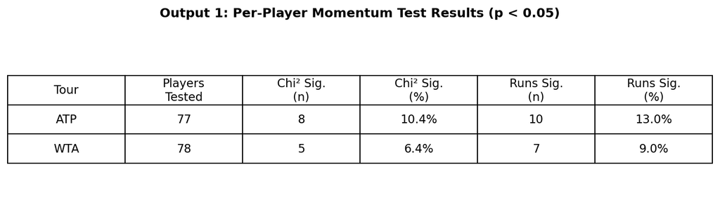

Per-player momentum test results across ATP and WTA

The results in Figure 1 are the first blow to the momentum theory. In the ATP, 10.4% of players showed statistically significant evidence via the Chi-squared test that their point sequences were non-random, with 13.0% significant on the runs test. In the WTA, 6.4% and 9.0% respectively. At a 5% significance threshold, random chance alone would produce roughly 5% significant results. Our figures exceed that but remain far below what widespread momentum would predict.

Figure 2 tracks the cumulative momentum score — a running total of how far a player’s performance drifts above or below their average — across a WTA match between Ekaterina Alexandrova and Madison Brengle, the longest in the WTA dataset by point count. The line rises when the player we are tracking is winning points above her average rate, and falls when she drops below it. A genuine momentum effect would look like a sustained climb, with the player catching fire and staying hot.

[interactive chart not shown]

What we actually see is oscillation. The line moves up, reverses, recovers, and reverses again. There are no sustained directional runs of the kind that a momentum narrative would predict. The pattern looks far more like the natural variance of a competitive match than evidence of a psychological force building behind one player.

## What About the Biggest Moments?

Perhaps momentum does not operate across an entire match; perhaps it concentrates in the highest-pressure moments. Break points. Tiebreaks. The moments where crowds hold their breath and commentators reach for their most dramatic vocabulary.

We tested this directly. For every player, we calculated their Tiebreak Over-Expectation (TBOE) — their actual tiebreak win rate minus their predicted win rate based on their official ranking and rolling form. A positive TBOE means a player outperforms expectations under pressure; a negative TBOE means they underperform. If certain players consistently raise their game when it matters most, we would expect to see clear outliers pulling away from zero in Figure 3.

[interactive chart not shown]

The chart reveals a systematic pattern rather than random scatter. Top-ranked players — those with the lowest ranking numbers — tend to have negative TBOE, meaning they underperform expectations in tiebreaks relative to their baseline skill. Lower-ranked players show positive TBOE, outperforming expectations. This is consistent with what you would expect from a top-heavy ranking system: the best players are already performing at such a high level that even their strong tiebreak performance falls slightly below their own elevated standard. There is no evidence of a consistent clutch performer who reliably over-delivers regardless of ranking — the pattern is driven by skill level, not psychological pressure response.

## Correlation or Causation?

Everything so far has tested whether momentum correlates with winning the next point. But correlation is not causation. A player who is already dominating will naturally win more break points — the association might simply reflect that good players win more of everything, not that winning one big point causes them to win the next.

We use a causal forest to estimate whether winning a pressure point causes a higher probability of winning the next — not just correlates with it. Standard regression cannot reliably estimate how this effect varies across different types of players and match contexts — the causal forest addresses this directly by estimating how the effect varies across different types of players, rather than assuming it is the same for everyone. More precisely, the causal forest estimates this effect conditional on observed match dynamics including player ranking, recent form, and cumulative momentum score. Since treatment is not randomly assigned, this remains an estimate based on observed data rather than a controlled experiment. The method uses sample splitting — one portion of the data determines the tree structure, another estimates the treatment effects within each leaf — which prevents the kind of overfitting that would make results look better than they really are.

We define a high-leverage win as a point where the player faced a break point or tiebreak situation and won it. This follows directly from the academic literature — Gilovich et al. (1985) and Miller and Sanjurjo (2018) both define momentum as success breeding success, not merely exposure to pressure. Crucially, we split these two types of pressure moment apart, because it turns out they behave very differently.

This approach controls for four variables: player ranking, rolling win percentage over the last ten points, winning streak length over the last four points, and cumulative momentum score — and asks: holding all of that constant, does winning a high-leverage point actually shift what happens next?

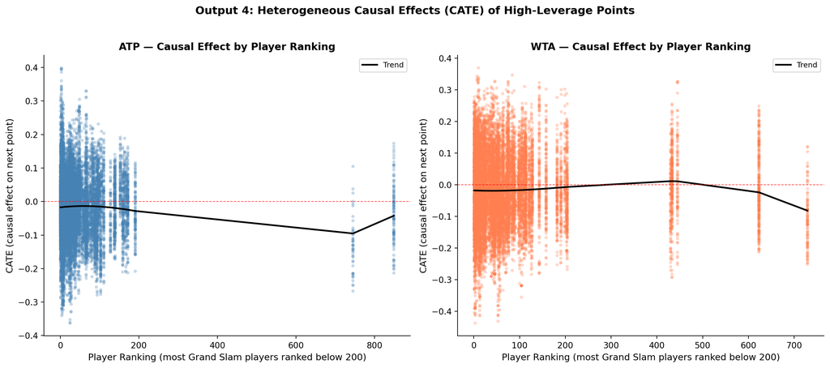

Causal effect of winning a high-leverage point, across player rankings

Figure 4 shows the Conditional Average Treatment Effect — the estimated causal effect for every observation in the dataset, plotted against player ranking. The scatter sits around zero across all ranking levels. Top-ranked players show no more momentum effect than qualifiers when looking at the combined picture. But this aggregate view conceals something important.

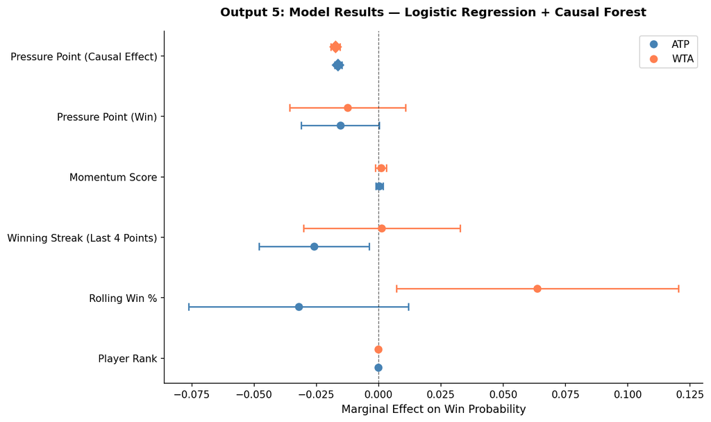

Model results, logistic regression and causal forest estimates

Figure 5 visualises the model results using two complementary approaches. The logistic regression establishes which variables are statistically associated with winning the next point, while the causal forest estimates the effect of high-leverage wins conditional on observed controls. The combined Average Treatment Effect is -0.0162 for ATP and -0.0173 for WTA — both negative and consistent across full and reduced control specifications.

## The Finding That Changes Everything

When we separate break points from tiebreaks, the aggregate picture breaks apart into something far more interesting.

Winning a break point — converting that crucial moment to take a game — causes a **hangover effect** in both tours. The ATP estimate is -0.0242 and the WTA estimate is -0.0164, both negative. Winning the break point appears to slightly reduce the probability of winning the next point. The player may relax, their opponent may raise their game in response, or the psychological weight of the conversion creates a momentary lapse. Whatever the mechanism, the data is consistent: break points do not generate momentum. They generate a small but measurable hangover.

Tiebreaks tell the opposite story. Winning a tiebreak point generates **genuine positive momentum** in both tours. The ATP estimate is +0.0564 and the WTA estimate is +0.0209, both positive. In the highest-stakes moments of a set — where every point directly determines whether you win or lose that set — winning appears to genuinely lift the probability of winning the next point. The WTA tiebreak estimate should be interpreted with caution given the small number of treated observations, but the direction is consistent with the ATP finding.

These two effects cancel each other out in the combined analysis, which is why earlier research treating all high-leverage moments as identical found no effect. The illusion of momentum — or its absence — depends entirely on which type of pressure moment you are looking at.

## If Not Momentum, Then What?

Outside of tiebreaks, if momentum does not drive point outcomes, what does? Figure 6 shows which variables actually matter, ranked by how much explanatory power they carry in our model.

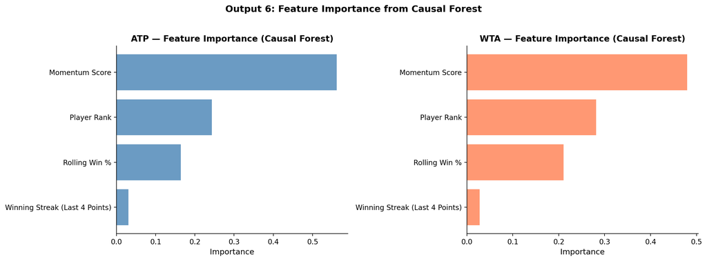

Causal Forest feature importance

The cumulative momentum score dominates in both tours — carrying roughly twice the predictive weight of player rank and three times that of rolling win percentage. This is a striking finding. The variable that best predicts whether a player wins the next point is not their recent form over ten points, nor their official ranking, but the accumulated drift of their performance across the entire match. This suggests that while momentum does not operate cleanly through individual pressure points, the broader pattern of a player’s performance within a match — their cumulative trajectory — does carry genuine predictive information.

This mirrors and extends the core insight of Gilovich, Vallone and Tversky — human observers are not entirely wrong to perceive momentum as a force, but they misattribute it. It is not generated by a single dramatic point, but accumulates across the match, embedded in the cumulative trajectory rather than in discrete psychological breakthroughs.

## The Uncomfortable Conclusion

Across 52,314 points, two tours, and four Grand Slams, the data tells a more nuanced story than either side of the momentum debate typically acknowledges.

Momentum is not a single phenomenon. Winning a break point appears to generate a small hangover effect — the opposite of what crowds expect. Winning a tiebreak point generates genuine positive momentum — exactly what crowds expect, but only in this specific context. The two effects are real, opposite in sign, and have been cancelling each other out in aggregate analyses that treat all pressure moments as identical.

This finding is robust across control specifications — results are consistent whether we control only for player ranking or include the full set of form variables — which reduces the concern that the result is an artefact of over-controlling.

There are honest limitations. This single-season dataset skews toward elite broadcast matches. We lack physiological data (like fatigue) to capture momentum invisible to point-level scoring. Winning a high-leverage point is not fully exogenous — it may reflect unobserved player state that simultaneously affects both current and next point outcomes. The standard errors in Figure 5 are descriptive approximations rather than formally derived causal forest inference, a consequence of memory constraints requiring stratified subsampling — the conclusions rest on consistency across specifications rather than any single interval. We test immediate point-to-point effects only; momentum may operate over longer horizons which this analysis does not capture.

But the picture is clearer than it has ever been at this scale. The next time a commentator says Alcaraz has the momentum after winning a break point, the data suggests scepticism is warranted. If he just won a tiebreak point, they might be onto something.

*Data: Jeff Sackmann Match Charting Project and ATP/WTA official results (2023). Full code and replication instructions at: https://github.com/flynnpresence/BEE2041-tennis-momentum*